# anova.hw

Author

Karli Balzanto

```r
library(tidyverse)
library(broom)
data(iris)
```

## problem 1

Does this sample data provide evidence that sepal width is dependent on species in the population from which this sample is drawn? Test at significance level $\alpha = .05$.

$H_0:$ The population mean sepal width is the same for all species.

$H_a:$ At least one species has a different population mean sepal width.

The ANOVA test produces a very small p-value (≪ 0.05); therefore, we reject $H_0$. There is strong statistical evidence that mean sepal width depends on species in the population of irises.

```r
mod1 <- aov(Sepal.Width ~ Species, data = iris)

summary(mod1)
```

```
             Df Sum Sq Mean Sq F value Pr(>F)
Species       2  11.35   5.672   49.16 <2e-16 ***
Residuals   147  16.96   0.115
---
Signif. codes:  0 '***' 0.001 '**' 0.01 '*' 0.05 '.' 0.1 ' ' 1
```

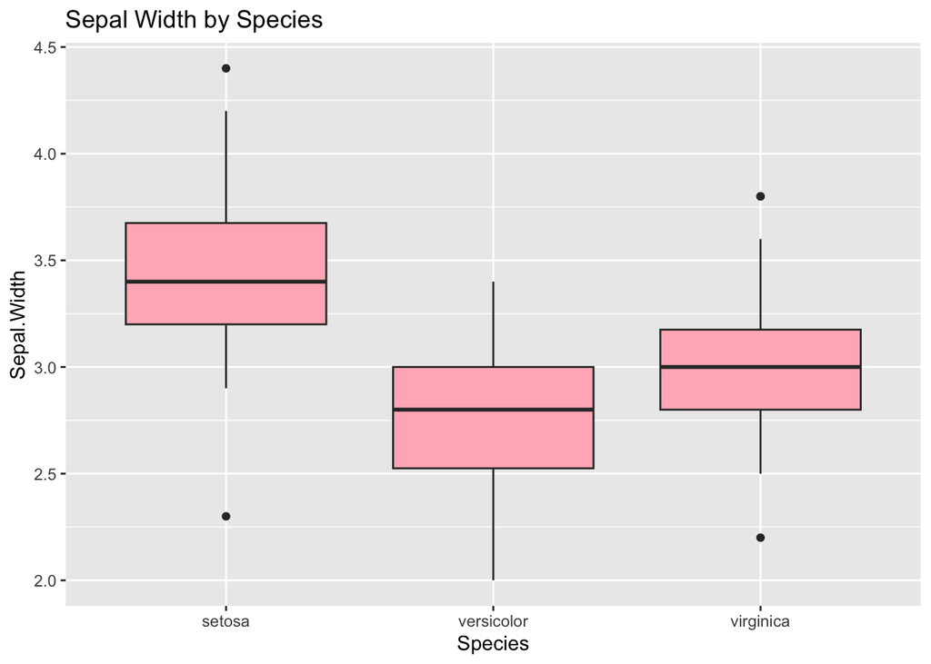

```r
#basic plot for my understanding
ggplot(iris,
       aes(x = Species,
           y = Sepal.Width)) +
  geom_boxplot(fill = "lightpink") +
  labs(title = "Sepal Width by Species")
```

## problem 2

Follow up on problem 1 by comparing mean sepal widths pairwise across different species using the post-hoc test covered in class.

```r
tukey_res <- TukeyHSD(mod1)
tukey_res
```

```
  Tukey multiple comparisons of means
    95% family-wise confidence level

Fit: aov(formula = Sepal.Width ~ Species, data = iris)

$Species
                       diff         lwr        upr     p adj
versicolor-setosa    -0.658 -0.81885528 -0.4971447 0.0000000
virginica-setosa     -0.454 -0.61485528 -0.2931447 0.0000000
virginica-versicolor  0.204  0.04314472  0.3648553 0.0087802
```

## problem 3

Is sepal width a statistically significant explainer of petal width? Follow all best-practices from class. (Remark: Your model should show a negative association between these variables, which would seem counter-intuitive.)

$PetalWidth= \beta_0 + \beta_1(SepalWidth)$

$H_0: \beta_1 = 0$ (sepal width is not associated with petal width)

$H_a: \beta_1 \ne 0$ (sepal width is associated with petal width)

The slope is negative and statistically significant (p < 0.001); therefore, we reject $H_0$ and conclude that sepal width is a significant predictor of petal width.

```r
mod2 <- lm(Petal.Width ~ Sepal.Width, data = iris)
summary(mod2)
```

```
Call:
lm(formula = Petal.Width ~ Sepal.Width, data = iris)

Residuals:
     Min       1Q   Median       3Q      Max
-1.38424 -0.60889 -0.03208  0.52691  1.64812

Coefficients:
            Estimate Std. Error t value Pr(>|t|)
(Intercept)   3.1569     0.4131   7.642 2.47e-12 ***
Sepal.Width  -0.6403     0.1338  -4.786 4.07e-06 ***
---
Signif. codes:  0 '***' 0.001 '**' 0.01 '*' 0.05 '.' 0.1 ' ' 1

Residual standard error: 0.7117 on 148 degrees of freedom
Multiple R-squared:  0.134, Adjusted R-squared:  0.1282
F-statistic: 22.91 on 1 and 148 DF,  p-value: 4.073e-06
```

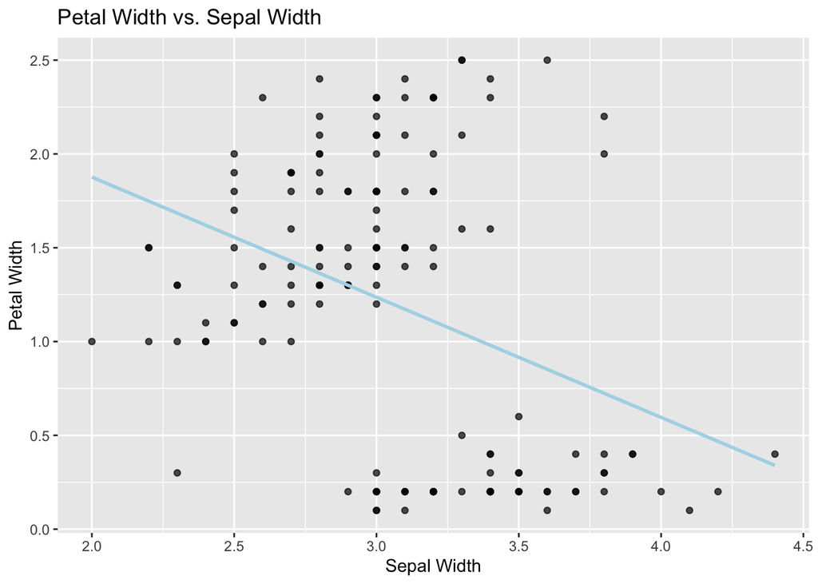

```r
ggplot(iris,
       aes(x = Sepal.Width,
           y = Petal.Width)) +
  geom_point(alpha = 0.7) +
  geom_smooth(method = "lm",
              se = FALSE,
              color = "lightblue") +
  labs(title = "Petal Width vs. Sepal Width",
       x = "Sepal Width",
       y = "Petal Width")
```

## problem 4

Construct a parallel-slopes model explaining petal width with sepal width and species. Write the equation of the model, making sure the meanings of your variables are clear. Also include a plot.

$PetalWidth= \beta_0 + \beta_1(SepalWidth) + \beta_2(Versicolor) + \beta_3(Virginica)$

Within each species, sepal width has only a weak relationship with petal width. Species mainly shifts the intercept upward or downward.

```r
mod3 <- lm(Petal.Width ~ Sepal.Width + Species, data = iris)
summary(mod3)
```

```
Call:
lm(formula = Petal.Width ~ Sepal.Width + Species, data = iris)

Residuals:
     Min       1Q   Median       3Q      Max
-0.51998 -0.09476 -0.01406  0.10161  0.42333

Coefficients:
                  Estimate Std. Error t value Pr(>|t|)
(Intercept)       -0.72577    0.15298  -4.744 4.94e-06 ***
Sepal.Width        0.28348    0.04400   6.443 1.59e-09 ***
Speciesversicolor  1.26653    0.04638  27.306  < 2e-16 ***
Speciesvirginica   1.90870    0.04138  46.127  < 2e-16 ***
---
Signif. codes:  0 '***' 0.001 '**' 0.01 '*' 0.05 '.' 0.1 ' ' 1

Residual standard error: 0.1812 on 146 degrees of freedom
Multiple R-squared:  0.9446,    Adjusted R-squared:  0.9435
F-statistic: 830.2 on 3 and 146 DF,  p-value: < 2.2e-16
```

[figure not shown]

```r
ggplot(iris,
       aes(x = Sepal.Width,
           y = Petal.Width,
           color = Species)) +
  geom_point() +
  geom_smooth(method = "lm",
              se = FALSE,
              color = 'grey') +
  labs(title = "Parallel-Slopes Model for Petal Width",
       x = "Sepal Width",
       y = "Petal Width",
       color = "Species")
```

## problem 5

Construct an attractive residual plot for the model in the last problem. Comment on any patterns that you observe.

the plot shows:

- No strong curvature → linearity is reasonable
- Roughly equal spread across fitted values → constant variance is reasonable
- Residuals centered around zero → model form is adequate
- Mild species clustering is expected but not concerning

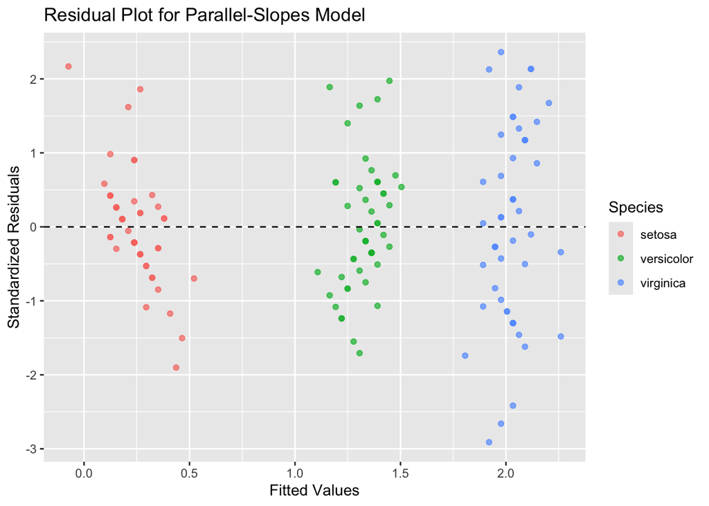

```r
resid_df <- augment(mod3)

ggplot(resid_df,
       aes(x = .fitted,
           y = .std.resid,
           color = iris$Species)) +
  geom_point(alpha = 0.7) +
  geom_hline(yintercept = 0,
             linetype = "dashed") +
  labs(title = "Residual Plot for Parallel-Slopes Model",
       x = "Fitted Values",
       y = "Standardized Residuals",
       color = "Species")
```